# Data Analysis report

**May 28, 2020**

## Overview:

- Analyze and communicate insights of cleaned dataset.

Using the clean dataset I wanted to answer the question: **What is/are the factor(s) of most rating dogs?**

First, I had to get the most rated dogs which are the dogs with highest rating_numerator and saved the dataframe to most_rated using this line of code:

`most_rated = df[df.rating_numerator==df.rating_numerator.max()]`

To answer the above question, I thought of exploring the dog_stage feature and see how it is related to most rating dogs.

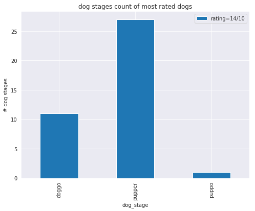

We can see that pupper dog_stage is the most occuring in this dataset, let's dig deeper.

Among those dog_stages I wanted to know which dog_stage received the most on twitter.

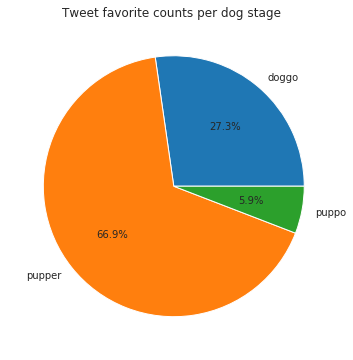

Pupper dog stage has the most favorite count among the most rated dogs

Next, I wanted to explore the dog breeds of the most rated dogs. I ended up with these results:

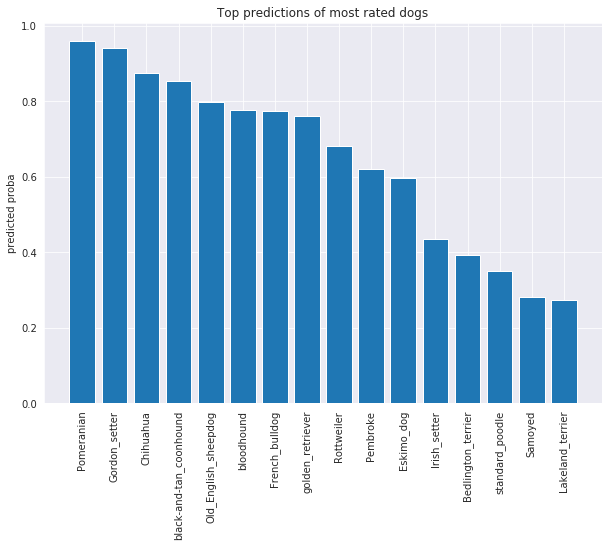

Top 3 predicted dog breeds are:

- Pomeranian
- Gordon Setter
- Chihuahua

These dog breeds share a common key factor, which is their **small size**

## Conclusion

We can conclude that pupper is the most rated and liked dog stage which makes sense according to the definition of a pupper from Dogtionary:

> Pupper: A small doggo, usually younger. Can be equally, if not more mature than some doggos

Even the detected dog breeds share acommon key factor which is the small size.

## Extra visualization

I wanted to make a word cloud of the tweets of the most rated dogs and among the most occuring words there is **pupper, doggo, pup, good, etc...**

[figure not shown]